# Normalized Turnout for Logan County, KS in General Election 2016-11-08

Earl F Glynn

2022-04-28

# 1 Setup

## 1.1

## 1.2 Constants

```r
EXCEL_LIMIT <- 2^20
```

```r
params
```

```
$AgeLimit
[1] 105

$ReportTitle
[1] "Normalized Turnout for Logan County, KS in General Election 2016-11-08"

$District
[1] "County"

$DistrictName
[1] "Logan"

$ElectionDate
[1] "2016-11-08 UTC"

$ElectionName
[1] "General"

$AfterFileDate
[1] "2017-02-13 UTC"

$PrecinctMinimum
[1] 25

$voterMaster
# A tibble: 1,794,928 x 20
   ID14         SOSKey Status BirthDate  RegisterDate Gender County City   Party
   <chr>         <dbl> <chr>  <date>     <date>       <chr>  <chr>  <chr>  <chr>
 1 ALFFC0813B~ 4476835 I      1979-03-17 1998-02-03   Female Allen  Iola   U
 2 AL038EF3B3~ 4482236 A      1948-07-09 1984-01-18   Male   Allen  Iola   D
 3 ALB787B84C~ 4479777 A      1938-05-14 2003-07-16   Male   Allen  Iola   R
 4 AL5B6D1A72~ 4472179 A      1950-09-27 1984-07-17   Female Allen  Iola   R
 5 AL1EF09FED~ 4481177 A      1941-05-24 2003-07-16   Female Allen  Iola   R
 6 ALA008B281~ 4479571 A      1958-04-10 2004-04-09   Female Allen  Chanu~ U
 7 ALF2585233~ 4508784 A      1982-01-06 2015-03-09   Male   Allen  Humbo~ U
 8 AL4BC0A7AA~ 5792061 A      1998-11-12 2016-03-21   Male   Allen  Humbo~ D
 9 AL12C597ED~ 5298896 A      1984-07-14 2009-02-06   Female Allen  Iola   U
10 AL28AD750A~ 4383859 I      1984-09-09 2008-02-26   Female Allen  Iola   U
# ... with 1,794,918 more rows, and 11 more variables: LastVoteYear <dbl>,
#   TotalVotes <dbl>, August <dbl>, AugPattern <chr>, November <dbl>,
#   NovPattern <chr>, Precinct <chr>, Age <dbl>, Registered <dbl>,
#   RegisteredTooLate <int>, VotedInElection <int>
```

## 1.3 Packages

```r
library(tidyverse)
library(lubridate)   # date functions
library(scales)      # comma

library(readxl)
library(writexl)
library(kableExtra)

library(gplots)      # heatmap.2
```

## 1.4 ggplot theme

```r
theme_set(theme_minimal() +

          theme(axis.text             = element_text(size = 10),
                axis.title            = element_text(size = 14),

                legend.position       = "bottom",

                plot.caption          = element_text(hjust = c(0.0,1.0),
                                                     size = 10),
                plot.caption.position = "plot",

                plot.title.position   = "plot",

                strip.background      = element_rect(fill = "aliceblue"),
                strip.text            = element_text(size = 14),

                title                 = element_text(size = 14)))
```

## 1.5 Helper Functions

```r
Show <- function(data, caption="", bigMark="", ...)
{
  data                                                    %>%
  kable("html",
        caption = caption,
        format.args = list(big.mark = bigMark))   %>%
  kable_styling(bootstrap_options = c("striped", "bordered", "condensed"),
                position = "left",
                full_width = FALSE, ...)
}
```

```r
ageDataByGroup <- function(VOTERS, GROUP)
{
  VOTERS                   %>%
  group_by(Age, {{GROUP}}) %>%
  summarize(Registered     = n(),
            Active         = sum(Status == "A",   na.rm = TRUE),
            Voted          = sum(VotedInElection, na.rm = TRUE),

            ActivePercent  = 100 * Active / Registered,
            VotedPercent   = 100 * Voted  / Registered,
            .groups = "drop")   %>%
  ungroup()
}
```

```r
bySummary <- function(VOTERS, GROUP)
{
  VOTERS               %>%
  group_by({{GROUP}})  %>%
  summarize(Registered = n(),
            Active     = sum(Status == "A",   na.rm = TRUE),
            Voted      = sum(VotedInElection, na.rm = TRUE),

            ActivePercent = 100 * Active / Registered,
            VotedPercent  = 100 * Voted  / Registered,
            .groups = "drop")   %>%
  ungroup()
}
```

# 2 Parameters

Use first publicly available voter list after a general election whenever possible.

```r
ELECTION_DATE    <- params$ElectionDate   # Use for age computations
AFTER_FILE_DATE  <- params$AfterFileDate

ELECTION_NAME    <- params$ElectionName

AGE_LIMIT        <- params$AgeLimit
PRECINCT_MINIMUM <- params$PrecinctMinimum

voterMaster      <- params$voterMaster
```

```r
FigureDistrict <- paste(params$DistrictName, params$District)
FigureTitle    <-  paste("Kansas", ELECTION_NAME, "Election", ELECTION_DATE)
Source         <- paste("Source:  Kansas Secretary of State, Voter File ",
                        AFTER_FILE_DATE)
Stamp          <- paste("efg", format(time.1, "%Y-%m-%d %H%M"))
```

# 3 Define Kansas Data

```r
cat("## Filter to Target", FigureDistrict, "\n")
```

## 3.1 Filter to Target Logan County

```r
if (params$District == "County")
{
  voterList <-
    voterMaster   %>%
    filter(County == params$DistrictName)
}
```

```r
cat("#", FigureDistrict, "Summary\n")
```

# 4 Logan County Summary

```r
voterList %>%
  summarize(
             n         = n(),
             nID14     = n_distinct(ID14),
             nSOSKey   = n_distinct(SOSKey),
             nVoted    = sum(VotedInElection, na.rm = TRUE),
             nParty    = n_distinct(Party),
             nGender   = n_distinct(Gender),
             nPrecinct = n_distinct(Precinct),
             minAge    = min(Age, na.rm = TRUE),
             maxAge    = max(Age, na.rm = TRUE)
            )  %>%
  Show(bigMark = ",")
```

| n | nID14 | nSOSKey | nVoted | nParty | nGender | nPrecinct | minAge | maxAge |
| --- | --- | --- | --- | --- | --- | --- | --- | --- |
| 1,852 | 1,851 | 1,852 | 1,388 | 4 | 2 | 15 | 18 | 103 |

When `nSOSKey` > `nID14` there are very likely some duplicate voter records that should be deleted.

Number of voters with age > 105 years old:

```r
tooOld <-
  voterList  %>%
  filter(Age > AGE_LIMIT | is.na(Age))

nrow(tooOld)
```

```
[1] 0
```

These “too old” voters (or those without age) written to file `Too-Old-Voters.xlsx’

```r
if (nrow(tooOld) > 0)
{
  write_xlsx(tooOld, paste0("Too-Old-Voters-", params$DistrictName, ".xlsx"))
}
```

Any too young?

```r
tooYoung <-
  voterList  %>%
  filter(Age < 18)

nrow(tooYoung)
```

```
[1] 0
```

```r
if (nrow(tooYoung) > 0)
{
  write_xlsx(tooYoung, paste0("Too-Young-Voters-", params$DistrictName, ".xlsx"))
}
```

Voter count after removal of “too young”, “too old” and missing age

```r
voterList <-
  voterList  %>%
  filter(Age >= 18,
         Age <= params$AgeLimit,
         !is.na(Age))

nrow(voterList)
```

```
[1] 1852
```

## 4.1 Counts by Age

Number of age intervals

```r
ageData  <-
  voterList            %>%
  group_by(Age)        %>%
  summarize(Registered = n(),
            Active     = sum(Status == "A",   na.rm = TRUE),
            Voted      = sum(VotedInElection, na.rm = TRUE),

            ActivePercent = 100 * Active / Registered,
            VotedPercent  = 100 * Voted  / Registered,
            .groups = "drop")   %>%
  ungroup()

nrow(ageData)
```

```
[1] 81
```

Total number of Registered, Active, Voted

```r
countsRegistered <- sum(ageData$Registered, na.rm = TRUE)
countsActive     <- sum(ageData$Active,     na.rm = TRUE)
countsVoted      <- sum(ageData$Voted,      na.rm = TRUE)

c(countsRegistered, countsActive, countsVoted)
```

```
[1] 1852 1832 1388
```

## 4.2 Voter Counts: Registered, Active, Voted by Age

```r
countPlotData <-
  ageData                                                       %>%
  select(Age,
         `Registered Voters` = Registered,
         `Active Voters`     = Active,
         `Ballots Cast`      = Voted)                           %>%     #####
  pivot_longer(-Age, names_to = "Group", values_to = "Voters")  %>%
  mutate(Group = factor(Group,  # control order for legend
                        levels = c("Registered Voters",
                                   "Active Voters",
                                   "Ballots Cast"))) %>%
  arrange(Group, Age)
```

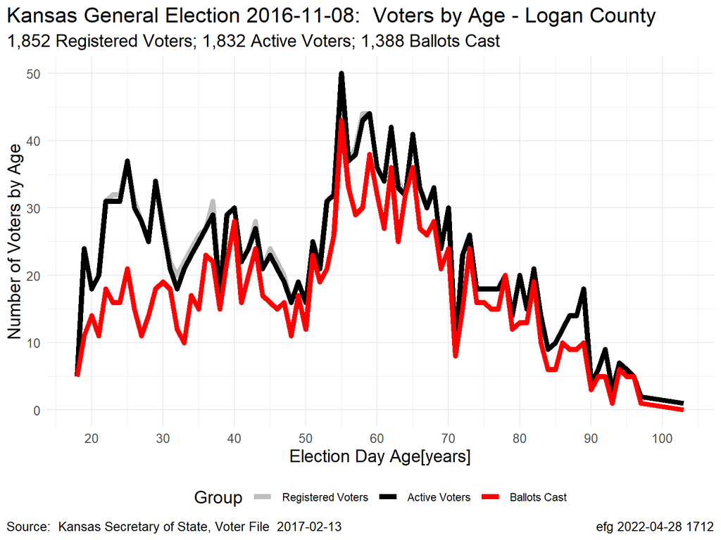

```r
registeredActiveVoted <-
  ggplot(countPlotData, aes(Age, y= Voters, color = Group)) +
  geom_line(size = 2)                                    +
  scale_y_continuous(labels = scales::comma)             +
  scale_x_continuous(breaks = 20 + 0:8 * 10)             +
  scale_color_manual(values = c("grey", "black", "red")) +
  labs(
        title = paste0(FigureTitle, ":  Voters by Age",
                       " - ", FigureDistrict),
        subtitle = paste0(comma(countsRegistered), " Registered Voters; ",
                          comma(countsActive),     " Active Voters; ",
                          comma(countsVoted),      " Ballots Cast "),
        x = "Election Day Age[years]",
        y = "Number of Voters by Age",
        caption = c(Source, Stamp)
      )

print(registeredActiveVoted)
```

## 4.3 Fraction of Registered Voters by Age: Active, Ballots Cast

```r
fractionPlotData <-
  ageData                                                        %>%
  select(Age,
         `Active Voters` = ActivePercent,
         `Ballots Cast`  = VotedPercent)                      %>%
  pivot_longer(-Age, names_to = "Group", values_to = "Percent")  %>%
  mutate(Group = factor(Group,  # control order for legend
                        levels = c("Active Voters", "Ballots Cast"))) %>%
  arrange(Group, Age)
```

```r
overallFractionActive = sum(ageData$Active) / sum(ageData$Registered)
overallFractionVoted  = sum(ageData$Voted)  / sum(ageData$Registered)

c(overallFractionActive, overallFractionVoted)
```

```
[1] 0.9892009 0.7494600
```

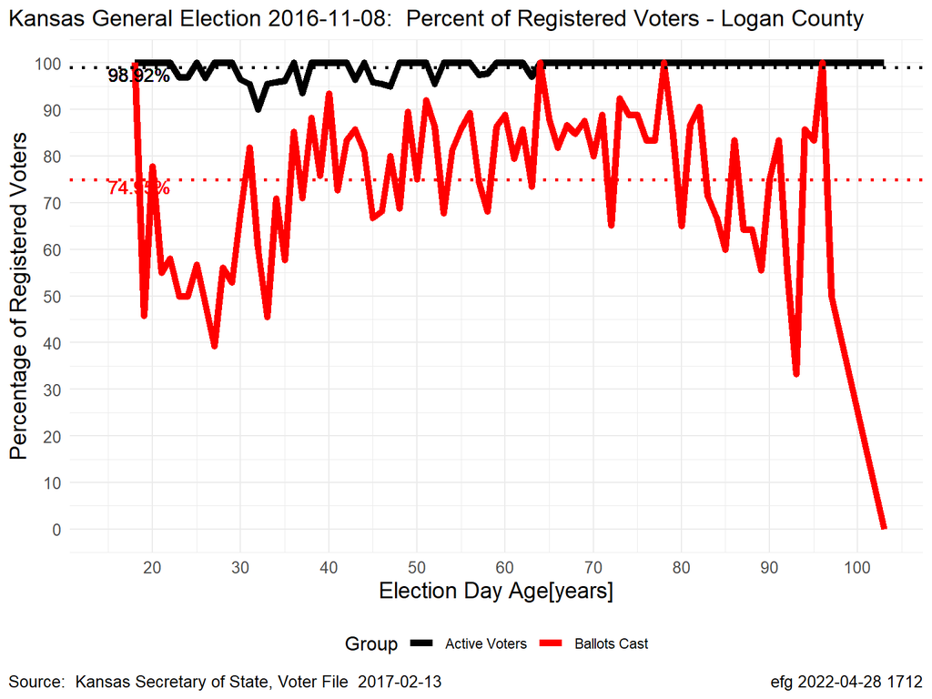

```r
activeVoted <-
  ggplot(fractionPlotData, aes(Age, y= Percent, color = Group))    +
  geom_line(size = 2)                                    +

  geom_hline(yintercept = 100 *overallFractionActive,
             color = "black",
             linetype = "dotted", size = 1)              +
  geom_text(aes(x = 15,
                y = 100 * overallFractionActive,
                label = paste0(round(100 * overallFractionActive, 2), "%")),
                color = "black", hjust = 0, vjust = 1, size = 4)   +

  geom_hline(yintercept = 100 *overallFractionVoted,
             color = "red",
             linetype = "dotted", size = 1)                        +
  geom_text(aes(x = 15,
                y = 100 * overallFractionVoted,
                label = paste0(round(100 * overallFractionVoted, 2), "%")),
                color = "red", hjust = 0, vjust = 1, size = 4)     +

  scale_y_continuous(breaks =      0:10 * 10)            +
  scale_x_continuous(breaks = 20 + 0: 8 * 10)            +
  scale_color_manual(values = c("black", "red"))         +
  labs(
        title = paste0(FigureTitle, ":  Percent of Registered Voters",
                       " - ", FigureDistrict),
        x = "Election Day Age[years]",
        y = "Percentage of Registered Voters",
        caption = c(Source, Stamp)
      )                                                  +
  theme(title = element_text(size = 12))

print(activeVoted)
```

## 4.4 Normalized Fraction

The normalization is formed by the ratio of turnout by age to the overall turnout for all ages (the dotted line in the diagram above).

What is the intuition for this normalization?

- Normalized fraction < 1 shows ages that “underperformed”.
- Normalized fraction > 1 shows ages that “outperformed”.
- Normalized fraction can be compared across different districts, like state and county.

```r
normalized <-
  ageData    %>%
  mutate(ActiveNormalized = (ActivePercent/100) / overallFractionActive,
         VotedNormalized  = (VotedPercent/100)  / overallFractionVoted)
```

```r
normalizedPlotData <-
  normalized                                                   %>%
  select(Age,
         `Active Voters` = ActiveNormalized,
         `Ballots Cast`  = VotedNormalized)                   %>%
  pivot_longer(-Age, names_to = "Group", values_to = "Ratio")  %>%
  mutate(Group = factor(Group,  # control order for legend
                        levels = c("Active Voters", "Ballots Cast"))) %>%
  arrange(Group, Age)
```

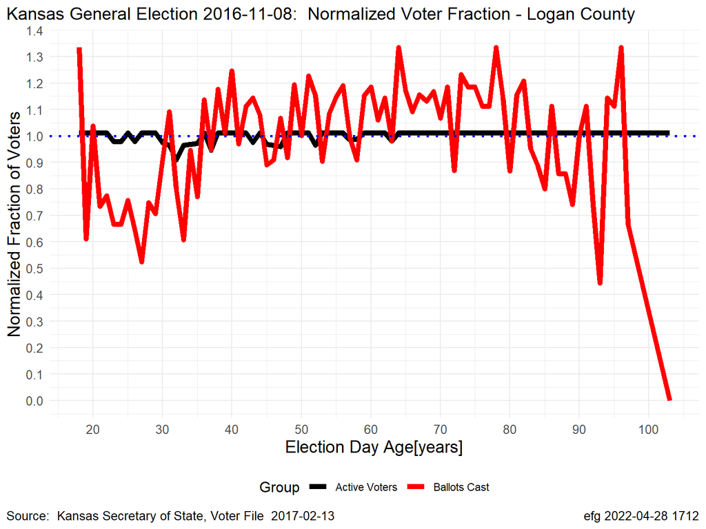

```r
normalizedVoted <-
  ggplot(normalizedPlotData, aes(Age, y= Ratio, color = Group))  +
  geom_line(size = 2)                                            +
  geom_hline(yintercept = 1.0, color = "blue",
             linetype = "dotted", size = 1)                      +
  scale_x_continuous(breaks = 20 + 0: 8 * 10)                    +
  scale_y_continuous(breaks = 0.01 * 0:24 * 10)                  +
  scale_color_manual(values = c("black", "red"))                 +
  labs(
        title = paste0(FigureTitle, ":  Normalized Voter Fraction",
                       " - ", FigureDistrict),
        x = "Election Day Age[years]",
        y = "Normalized Fraction of Voters",
        caption = c(Source, Stamp)
      )                                                          +
  theme(title = element_text(size = 12))

print(normalizedVoted)
```

# 5 By Party

```r
ageDataByParty <- ageDataByGroup(voterList, Party)
nrow(ageDataByParty)
```

```
[1] 220
```

```r
byParty <- bySummary(voterList, Party)
byParty %>%  Show()
```

| Party | Registered | Active | Voted | ActivePercent | VotedPercent |
| --- | --- | --- | --- | --- | --- |
| D | 207 | 206 | 151 | 99.51691 | 72.94686 |
| L | 8 | 7 | 3 | 87.50000 | 37.50000 |
| R | 1364 | 1354 | 1104 | 99.26686 | 80.93842 |
| U | 273 | 265 | 130 | 97.06960 | 47.61905 |

```r
countPlotDataByParty <-
  ageDataByParty                                                %>%
  select(Age, Party,
         `Registered Voters` = Registered,
         `Active Voters`     = Active,
         `Ballots Cast`      = Voted)                           %>%     #####
  pivot_longer(c(-Age,-Party), names_to = "Group", values_to = "Voters")  %>%
  mutate(Group = factor(Group,  # control order for legend
                        levels = c("Registered Voters",
                                   "Active Voters",
                                   "Ballots Cast"))) %>%
  arrange(Group, Age, Party)

nrow(countPlotDataByParty)
```

```
[1] 660
```

## 5.1 Voter Registration Counts

```r
partyCounts <- table(voterList$Party)
partyCounts
```

```
   D    L    R    U
 207    8 1364  273
```

```r
partyLabel <- c("D" = paste("Democratic",   comma(partyCounts["D"])),
                "L" = paste("Libertarian",  comma(partyCounts["L"])),
                "R" = paste("Republican",   comma(partyCounts["R"])),
                "U" = paste("Unaffiliated", comma(partyCounts["U"])))
```

```r
if (length(partyCounts) == 5)   # 2010 and earlier
{
  partyLabel = c(partyLabel[1],
                 "F" = paste("Reform",  comma(partyCounts["F"])),
                 partyLabel[2:4])
}
```

```r
registeredActiveVotedByParty <-
  ggplot(countPlotDataByParty,
         aes(x = Age, y= Voters, color = Group))         +
  geom_line(size = 2)                                    +
  scale_y_continuous(labels = scales::comma)             +
  scale_x_continuous(breaks = 20 + 0:8 * 10)             +
  scale_color_manual(values = c("grey", "black", "red")) +
  labs(
        title = paste0(FigureTitle, ":  Voters by Party and Age",
                       " - ", FigureDistrict),
        x = "Election Day Age[years]",
        y = "Number of Voters by Age",
        caption = c(Source, Stamp)
      )                                                  +
  theme(panel.grid.minor.x = element_blank())            +
  facet_wrap(~Party,
             ncol = length(partyLabel),
             labeller = labeller(Party = partyLabel))    +
  geom_text(data = byParty,
            aes(x = 15,
                y = Inf,
                label = paste0(comma(Active), " Active Voters\n",
                               comma(Voted),  " Ballots Cast")),
            color = "black", hjust = 0, vjust = 1, size = 4)
```

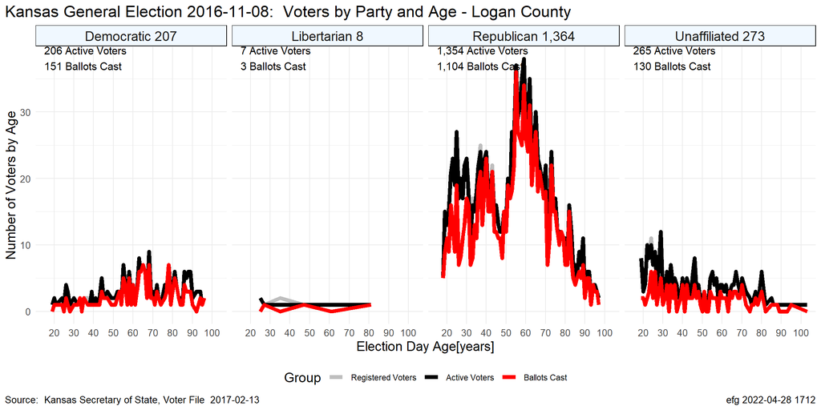

```r
print(registeredActiveVotedByParty)
```

## 5.2 Fraction of Voters

```r
partyLabelFraction <-
  c("D" = paste0("Democratic ",
                 round(100 * partyCounts["D"] / sum(partyCounts), 2), "%"),

    "L" = paste0("Libertarian ",
                 round(100 * partyCounts["L"] / sum(partyCounts), 2), "%"),

    "R" = paste0("Republican ",
                 round(100 * partyCounts["R"] / sum(partyCounts), 2), "%"),

    "U" = paste0("Unaffiliated ",
                 round(100 * partyCounts["U"] / sum(partyCounts), 2), "%"))
```

```r
if (length(partyCounts) == 5)   # 2010 and earlier
{
  partyLabelFraction = c(partyLabelFraction[1],
                         "F" = paste0("Reform ",
                                      round(100 * partyCounts["F"] / sum(partyCounts), 2), "%"),
                         partyLabelFraction[2:4])
}
```

```r
fractionByPartyAge <-
  ageDataByParty                                                      %>%
  select(Age, Party,
         `Active Voters` = ActivePercent,
         `Ballots Cast`  = VotedPercent)                               %>%
  pivot_longer(c(-Age, -Party), names_to = "Group", values_to = "Percent")  %>%
  mutate(Group = factor(Group,  # control order for legend
                        levels = c("Active Voters", "Ballots Cast")))  %>%
  arrange(Group, Age, Party)
```

```r
fractionByParty <-
  ageDataByParty
```

```r
activeVotedByParty <-
  ggplot(fractionByPartyAge, aes(Age, y= Percent, color = Group)) +
  geom_line(size = 2)                                    +
  scale_y_continuous(breaks =      0:10 * 10)            +
  scale_x_continuous(breaks = 20 + 0: 8 * 10)            +
  scale_color_manual(values = c("black", "red")) +
  labs(
        title = paste0(FigureTitle, ":  Percentage of Registered Voters by Party and Age",
                       " - ", FigureDistrict),
        x = "Election Day Age[years]",
        y = "Percentage of Registered Voters",
        caption = c(Source, Stamp)
      )                                                  +
  theme(panel.grid.minor.x = element_blank(),
        panel.grid.minor.y = element_blank())            +

  facet_grid(col = vars(Party),
             labeller = labeller(Party = partyLabelFraction),
             scales = "free_x")                          +

  geom_hline(data = byParty,
             aes(yintercept = ActivePercent),
             color = "black",
             linetype = "dotted", size = 1)              +
  geom_text(data = byParty,
            aes(x = 15,
                y = ActivePercent,
                label = paste0(round(ActivePercent, 1), "%")),
            color = "black", hjust = 0, vjust = 1, size = 4)   +

  geom_hline(data = byParty,
             aes(yintercept = VotedPercent),
             color = "red",
             linetype = "dotted", size = 1)               +
  geom_text(data = byParty,
            aes(x = 15,
                y = VotedPercent,
                label = paste0(round(VotedPercent, 1), "%")),
            color = "red", hjust = 0, vjust = 1, size = 4)
```

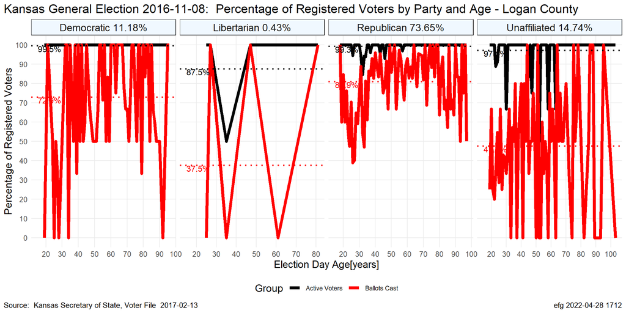

```r
print(activeVotedByParty)
```

# 6 By Gender

```r
ageDataByGender <- ageDataByGroup(voterList, Gender)
nrow(ageDataByGender)
```

```
[1] 159
```

```r
byGender <- bySummary(voterList, Gender)
byGender %>% Show()
```

| Gender | Registered | Active | Voted | ActivePercent | VotedPercent |
| --- | --- | --- | --- | --- | --- |
| Female | 937 | 925 | 720 | 98.71932 | 76.84098 |
| Male | 915 | 907 | 668 | 99.12568 | 73.00546 |

```r
countPlotDataByGender <-
  ageDataByGender                                               %>%
  select(Age, Gender,
         `Registered Voters` = Registered,
         `Active Voters`     = Active,
         `Ballots Cast`      = Voted)                           %>%     #####
  pivot_longer(c(-Age,-Gender), names_to = "Group", values_to = "Voters")  %>%
  mutate(Group = factor(Group,  # control order for legend
                        levels = c("Registered Voters",
                                   "Active Voters",
                                   "Ballots Cast"))) %>%
  arrange(Group, Age, Gender)

nrow(countPlotDataByGender)
```

```
[1] 477
```

## 6.1 Voter Registration Counts

```r
genderCounts <- table(voterList$Gender)
genderCounts
```

```
Female   Male
   937    915
```

```r
genderLabel <- c("Female"  = paste("Female",  comma(genderCounts["Female"])),
                 "Male"    = paste("Male",    comma(genderCounts["Male"])),
                 "Unknown" = paste("Unknown", comma(genderCounts["Unknown"])))
```

```r
registeredActiveVotedByGender <-
  ggplot(countPlotDataByGender,
         aes(x = Age, y= Voters, color = Group))         +
  geom_line(size = 2)                                    +
  scale_y_continuous(labels = scales::comma)             +
  scale_x_continuous(breaks = 20 + 0:8 * 10)             +
  scale_color_manual(values = c("grey", "black", "red")) +
  labs(
        title = paste0(FigureTitle, ":  By Gender and Age",
                       " - ", FigureDistrict),
        x = "Election Day Age[years]",
        y = "Number of Voters by Age",
        caption = c(Source, Stamp)
      )                                                  +
  theme(panel.grid.minor.x = element_blank())            +
  facet_wrap(~Gender,
             ncol = length(genderLabel),
             labeller = labeller(Gender = genderLabel))    +
  geom_text(data = byGender,
            aes(x = 15,
                y = Inf,
                label = paste0(comma(Active), " Active Voters\n",
                               comma(Voted),  " Ballots Cast")),
            color = "black", hjust = 0, vjust = 1, size = 4)
```

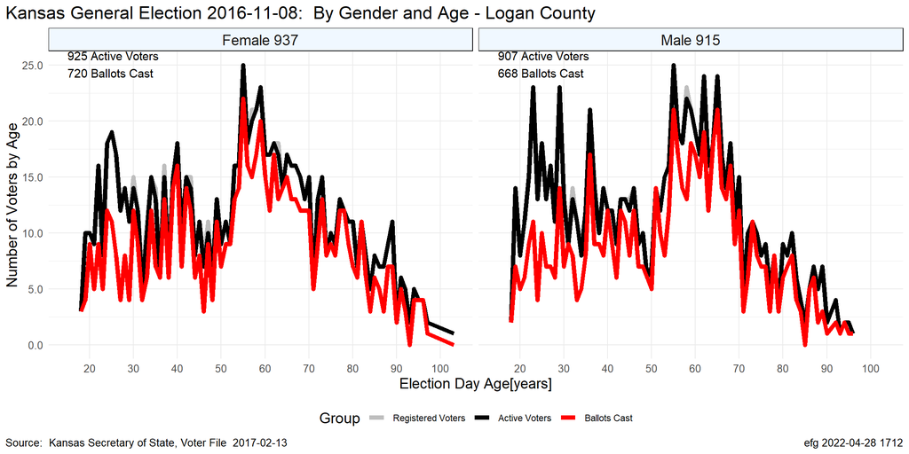

```r
print(registeredActiveVotedByGender)
```

## 6.2 Fraction of Voters

```r
genderLabelFraction <-
  c("Female" = paste0("Female ",
                 round(100 * genderCounts["Female"]  / sum(genderCounts), 2), "%"),

    "Male" = paste0("Male ",
                 round(100 * genderCounts["Male"]    / sum(genderCounts), 2), "%"),

    "Unknown" = paste0("Unknown ",
                 round(100 * genderCounts["Unknown"] / sum(genderCounts), 2), "%"))
```

```r
fractionByGenderAge <-
  ageDataByGender                                                     %>%
  select(Age, Gender,
         `Active Voter` = ActivePercent,
         `Ballots Cast` = VotedPercent)                               %>%
  pivot_longer(c(-Age, -Gender), names_to = "Group", values_to = "Percent")  %>%
  mutate(Group = factor(Group,  # control order for legend
                        levels = c("Active Voter", "Ballots Cast")))  %>%
  arrange(Group, Age, Gender)
```

```r
fractionByGender <-
  ageDataByGender
```

```r
activeVotedByGender <-
  ggplot(fractionByGenderAge, aes(Age, y= Percent, color = Group)) +
  geom_line(size = 2)                                    +
  scale_y_continuous(breaks =      0:10 * 10)            +
  scale_x_continuous(breaks = 20 + 0: 8 * 10)            +
  scale_color_manual(values = c("black", "red")) +
  labs(
        title = paste0(FigureTitle, ":  Percentage By Gender and Age",
                       " - ", FigureDistrict),
        x = "Election Day Age[years]",
        y = "Percentage of Registered Voters",
        caption = c(Source, Stamp)
      )                                                  +
  theme(panel.grid.minor.x = element_blank(),
        panel.grid.minor.y = element_blank())            +

  facet_grid(col = vars(Gender),
             labeller = labeller(Gender = genderLabelFraction),
             scales = "free_x")                          +

  geom_hline(data = byGender,
             aes(yintercept = ActivePercent),
             color = "black",
             linetype = "dotted", size = 1)              +
  geom_text(data = byGender,
            aes(x = 15,
                y = ActivePercent,
                label = paste0(round(ActivePercent, 1), "%")),
            color = "black", hjust = 0, vjust = 1, size = 4)   +

  geom_hline(data = byGender,
             aes(yintercept = VotedPercent),
             color = "red",
             linetype = "dotted", size = 1)               +
  geom_text(data = byGender,
            aes(x = 15,
                y = VotedPercent,
                label = paste0(round(VotedPercent, 1), "%")),
            color = "red", hjust = 0, vjust = 1, size = 4)
```

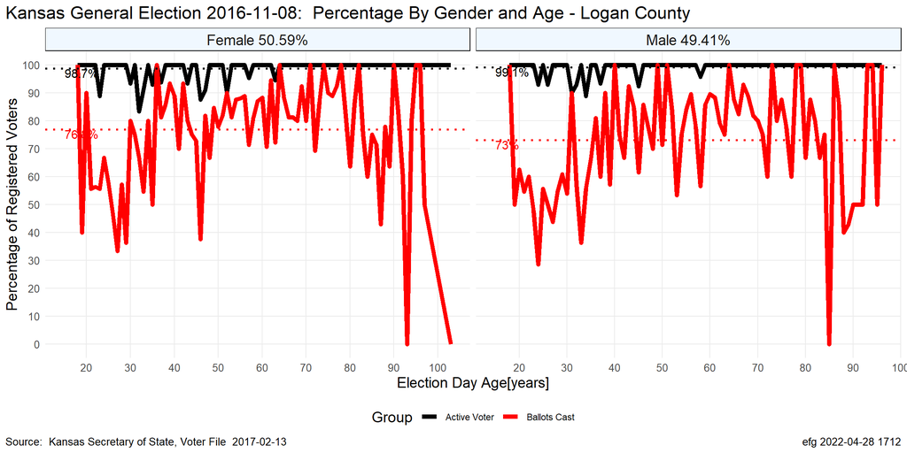

```r
print(activeVotedByGender)
```

# 7 By Precinct

```r
ageDataByPrecinct <- ageDataByGroup(voterList, Precinct)
nrow(ageDataByPrecinct)
```

```
[1] 397
```

```r
byPrecinct <-
  bySummary(voterList, Precinct)  %>%
  rename(OverallActivePercent = ActivePercent,
         OverallVotedPercent  = VotedPercent)
byPrecinct %>%  Show(bigMark = ",") %>%  scroll_box(height = "300px")
```

| Precinct | Registered | Active | Voted | OverallActivePercent | OverallVotedPercent |
| --- | --- | --- | --- | --- | --- |
| LG- - NA | 2 | 0 | 0 | 0.00000 | 0.00000 |
| LG-101 - Oakley City | 1,301 | 1,292 | 951 | 99.30822 | 73.09762 |
| LG-20RS - Russell Springs City | 13 | 13 | 8 | 100.00000 | 61.53846 |
| LG-30WI - Winona City | 121 | 120 | 96 | 99.17355 | 79.33884 |
| LG-AU0AU - Augustine Twp. | 9 | 9 | 8 | 100.00000 | 88.88889 |
| LG-EL0EL - Elkader Twp. | 8 | 8 | 8 | 100.00000 | 100.00000 |
| LG-LE0LE - Lees Twp. | 10 | 8 | 8 | 80.00000 | 80.00000 |
| LG-LO0LO - Logansport Twp. | 4 | 4 | 3 | 100.00000 | 75.00000 |
| LG-MC0MC - McAllaster Twp. | 21 | 21 | 16 | 100.00000 | 76.19048 |
| LG-MO0MO - Monument Twp. | 91 | 90 | 73 | 98.90110 | 80.21978 |
| LG-OA01 - Oakley Twp. | 138 | 138 | 112 | 100.00000 | 81.15942 |
| LG-PA0PA - Paxton Twp. | 25 | 24 | 21 | 96.00000 | 84.00000 |
| LG-RS0RS - Russell Springs Twp. | 26 | 24 | 20 | 92.30769 | 76.92308 |
| LG-WE0WE - Western Twp. | 34 | 34 | 26 | 100.00000 | 76.47059 |
| LG-WI0WI - Winona Twp. | 49 | 47 | 38 | 95.91837 | 77.55102 |

## 7.1 Precinct Size

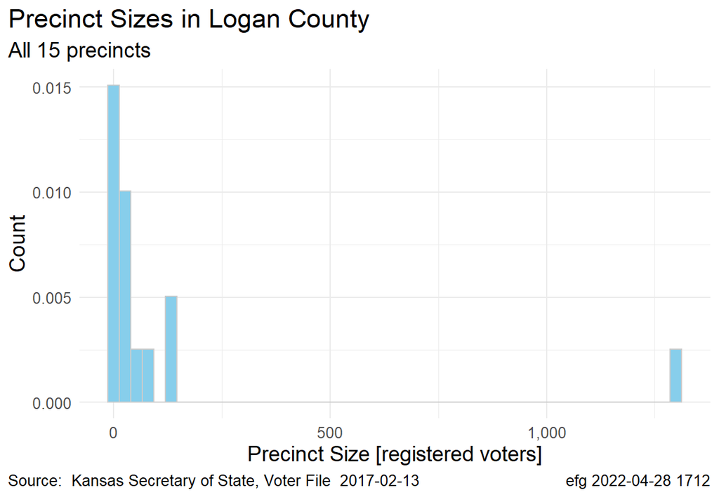

```r
ggplot(byPrecinct, aes(x = Registered, y=..density..))          +
  geom_histogram(fill = "skyblue", color = "grey80", bins = 50) +
  scale_x_continuous(labels = scales::comma)                    +
  labs(title = paste("Precinct Sizes in", FigureDistrict),
       subtitle = paste("All", nrow(byPrecinct), "precincts"),
       x = "Precinct Size [registered voters]",
       y = "Count",
       caption=c(Source, Stamp))
```

```r
largeEnough   <-
  byPrecinct  %>%
  filter(Registered >= PRECINCT_MINIMUM)

nrow(largeEnough)
```

```
[1] 8
```

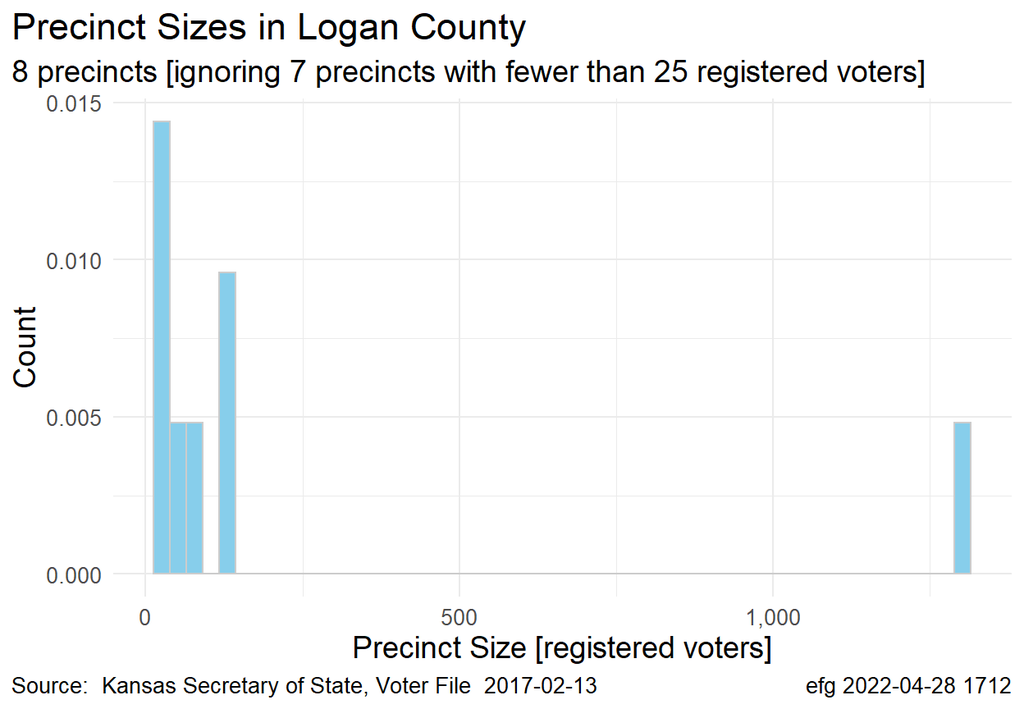

```r
ggplot(largeEnough, aes(x = Registered, y=..density..))          +
  geom_histogram(fill = "skyblue", color = "grey80", bins = 50)  +
  scale_x_continuous(labels = scales::comma)                     +
  labs(title = paste("Precinct Sizes in", FigureDistrict),
       subtitle = paste0(nrow(largeEnough), " precincts",
                      " [ignoring ", nrow(byPrecinct) - nrow(largeEnough),
                      " precincts with fewer than ", PRECINCT_MINIMUM, " registered voters]"),
       x = "Precinct Size [registered voters]",
       y = "Count",
       caption=c(Source, Stamp))
```

For now, let’s only look at voter turnout.

```r
normalizedAgeDataByPrecinct <-
  byPrecinct                                   %>%
  select(Precinct, OverallVotedPercent)        %>%
  inner_join(ageDataByPrecinct,
             by = "Precinct")                  %>%
  mutate(NormalizedFractionVoted = VotedPercent / OverallVotedPercent)  %>%
  select(Precinct, Age, NormalizedFractionVoted) %>%
  arrange(Precinct, Age)

dim(normalizedAgeDataByPrecinct)
```

```
[1] 397   3
```

## 7.2 Voter Registration Counts

```r
precinctCounts <- table(voterList$Precinct)
```

```r
sum(precinctCounts)
```

```
[1] 1852
```

## 7.3 Scatterplot of County Overall with All Precincts

```r
countyNormalized <-
  normalizedPlotData                       %>%
  rename(NormalizedFractionVoted = Ratio)  %>%
  filter(Group == "Ballots Cast")          %>%
  select(-Group)                           %>%
  mutate(Precinct = params$DistrictName)   %>%
  relocate(Precinct, .before = Age)

dim(countyNormalized)
```

```
[1] 81  3
```

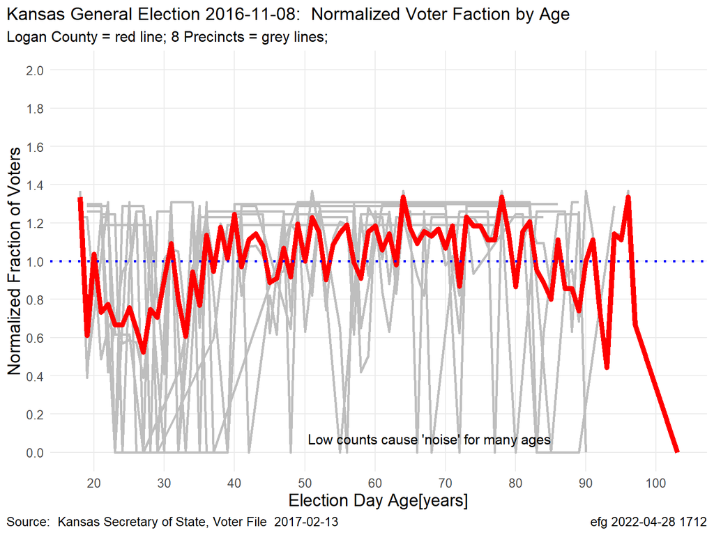

```r
normalizedVoted <-
  ggplot()                                      +

  geom_line(data = semi_join(normalizedAgeDataByPrecinct,
                             largeEnough,
                             by = "Precinct"),
            aes(x = Age, y= NormalizedFractionVoted,
                group = Precinct),
            color = "grey", size = 1)           +

  geom_line(data = countyNormalized,
            aes(x = Age, y= NormalizedFractionVoted),
            color = "red", size = 2)            +

  geom_hline(yintercept = 1.0, color = "blue",
             linetype = "dotted", size = 1)     +

  geom_text(aes(x = 85,
                y = 0.1,
                label = "Low counts cause 'noise' for many ages"),
            color = "black", hjust = 1, vjust = 1, size = 4)   +

  scale_x_continuous(breaks = 2:10 * 10)        +
  scale_y_continuous(breaks = 0:10 * 0.2,
                     limits = c(0, 2.0) )       +

  labs(
        title = paste0(FigureTitle, ":  Normalized Voter Faction by Age"),
        subtitle = paste0(FigureDistrict, " = red line; ",
                          nrow(largeEnough), " Precincts = grey lines;"),
        x = "Election Day Age[years]",
        y = "Normalized Fraction of Voters",
        caption = c(Source, Stamp)
      )                                         +
  theme(
         panel.grid.minor.x = element_blank(),
         panel.grid.minor.y = element_blank(),
         title = element_text(size = 12)
       )

print(normalizedVoted)
```

## 7.4 Heatmap

Create matrix

```r
County <-
  bind_rows(countyNormalized,
            semi_join(normalizedAgeDataByPrecinct,
                             largeEnough,
                             by = "Precinct"),)  %>%
  pivot_wider(names_from = Age,
              values_from = NormalizedFractionVoted,
              values_fill = list(NormalizedFractionVoted = 0))  %>%
  mutate(across(everything(), ~replace_na(.x, 0)))   # kludge fix (e.g., Primary 2006)
```

```r
comparisonMatrix <- as.matrix(County %>% select(-Precinct))
dim(comparisonMatrix)
```

```
[1]  9 81
```

```r
dimnames(comparisonMatrix) <- list(
                                    County$Precinct,
                                    colnames(County[-1]) %>% as.numeric()
                                   )
```

```r
ratioStats <- fivenum(comparisonMatrix)

ratioStats
```

```
[1] 0.0000000 0.0000000 0.5952381 1.2160299 1.3680336
```

```r
colorBreaks <-
  c(
    seq(0.0, 1.0, length.out = 12),
    seq(1.0, 2.0, length.out = 6)[-1]
  )

colorBreaks
```

```
 [1] 0.00000000 0.09090909 0.18181818 0.27272727 0.36363636 0.45454545
 [7] 0.54545455 0.63636364 0.72727273 0.81818182 0.90909091 1.00000000
[13] 1.20000000 1.40000000 1.60000000 1.80000000 2.00000000
```

Attempt to “balance” palette above and below 1.

```r
colorPalette <-
  c(colorRampPalette(c("red",   "white"))(12)[1:11],    # skip last
    "#FFFFFF",                                        # color for ratio of 1
    colorRampPalette(c("white", "skyblue"))(5)[2:5])  # skip first

colorPalette
```

```
 [1] "#FF0000" "#FF1717" "#FF2E2E" "#FF4545" "#FF5C5C" "#FF7373" "#FF8B8B"
 [8] "#FFA2A2" "#FFB9B9" "#FFD0D0" "#FFE7E7" "#FFFFFF" "#E1F2FA" "#C3E6F4"
[15] "#A5DAF0" "#87CEEB"
```

```r
# layout matrix 1 = heatmap, 2 = row dendrogrm, 3 = column dendrogram, 4 = key
lmat <- rbind( c(0, 3, 3),  # layout matrix
               c(2, 1, 1),
               c(0, 0, 4))

lwid <- c(3, 4, 4)          # entry for each column in layout matrix

# relative height of the rows. must have length = nrow(lmat)
lhei <- c(0.25, 4, 0.25)    # entry for each row in layout matrix
```

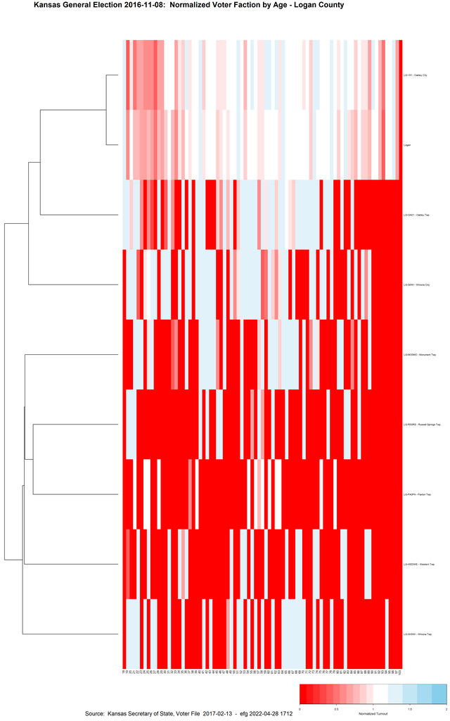

```r
oldPar <- par(mar = c(5, 0, 2, 16))

heatmap.2(
           comparisonMatrix,
           scale      = "none",
           dendrogram = "row",
           Colv       = NA,         # suppress reordering of columns

           trace  = "none",         # turns off trace lines inside the heat map
           col    = colorPalette,
           breaks = colorBreaks,

           margins = c(4, 16),      # column and row names

           cexRow = 1,
           cexCol = 1.25,

           key.title = NA,           # suppress title
           key.xlab  = "Normalized Turnout",
           keysize   = 3,
           density.info = "none",    # turns off density plot inside color legend

           lmat = lmat, lwid = lwid, lhei = lhei
         )

title(main = paste0(FigureTitle,
                    ":  Normalized Voter Faction by Age - ",
                    FigureDistrict),
      cex.main = 2,
      sub = paste(Source, " - ", Stamp),
      cex.sub  = 1.5)

par(oldPar)
```

# 8 Fini

## 8.1

Processing time: 8.5 secs

2022-04-28 1712